# Using the `PrivLCM’ package

Michelle Nixon

1/5/2022

Welcome! The privLCM package provides an interface to creating differentially-private contingency tables using a Bayesian Latent Class approach. Samples can be drawn using the `mcmc.sampler` function in the package.

This function works for any binary table of arbitrary dimension. However, computation times can be long if dimension and/or the number of latent classes is high. This is primarily due to the computation of the two-way marginal probabilities which requires enumerating over all possible combinations of the other variables.

### A Simple Example

We will implement our method using a $2^5$ table with $G=3$ latent classes. First, let’s simulate some data. Let N = 10,000.

```r
set.seed(1234)
N=10000
P=5

##Simulating data
prob_var = runif(5)

##Creating the data frame
df = data.frame("Var1" = sample(1:2, N, replace = TRUE, prob = c(prob_var[1], 1-prob_var[1])),
                "Var2" = sample(1:2, N, replace = TRUE, prob = c(prob_var[2], 1-prob_var[2])),
                "Var3" = sample(1:2, N, replace = TRUE, prob = c(prob_var[3], 1-prob_var[3])),
                "Var4" = sample(1:2, N, replace = TRUE, prob = c(prob_var[4], 1-prob_var[4])),
                "Var5" = sample(1:2, N, replace = TRUE, prob = c(prob_var[5], 1-prob_var[5])))

head(df)
```

```
##   Var1 Var2 Var3 Var4 Var5
## 1    2    1    1    2    2
## 2    2    1    1    2    1
## 3    2    1    1    2    1
## 4    2    1    2    2    1
## 5    2    1    1    2    1
## 6    2    2    1    1    1
```

Now, we need to calculate the two-way marginals. `privLCM` also requires a matrix that encodes what each count represent. This matrix should only have two non-`NA` entries per row. The other two entries denote which variables (as denoted by column position) and values (as denoted by a `1` or `2` in each row). The first row of the matrix tells the sampler which marginal the first count represents and so on. Let’s calculate both pieces:

```r
freq = c()
P = 5
comb.mat = matrix(ncol = P)

for(i in 1:(P-1)){
  for(j in (i+1):P){
    counts = plyr::count(df[,c(i,j)])
    freq = c(freq, counts$freq)
    tmp.mat = matrix(NA, nrow = 4, ncol = P)
    tmp.mat[,i] = counts[,1]
    tmp.mat[,j] = counts[,2]
    comb.mat = rbind(comb.mat, tmp.mat)
  }
}

comb.mat = comb.mat[-1,]
head(comb.mat)
```

```
##      [,1] [,2] [,3] [,4] [,5]
## [1,]    1    1   NA   NA   NA
## [2,]    1    2   NA   NA   NA
## [3,]    2    1   NA   NA   NA
## [4,]    2    2   NA   NA   NA
## [5,]    1   NA    1   NA   NA
## [6,]    1   NA    2   NA   NA
```

Now, we are ready to go! Other inputs that we need to specifiy are `P` which denotes the dimension of the table (in this case 5), `G` which denotes the number of latent classes, `eps` denotes the desired epsilon value, and `samp.size` which denotes number of observations in the data. We can also control the number of samples drawn with `nsamples`.

```r
library(privLCM)
library(data.table)
library(Rfast)
library(parallel)

cl = makeCluster(detectCores()-1)
clusterExport(cl, varlist = c("twoWay.probs.vectorized", "row.prob.vec","getProbs", "data.table", "rowprods", "P"))

samps = mcmc.sampler(freq, comb.mat, eps = 1, P = P, G = 3, nsamples = 5000, samp.size = N, cl = cl, .PiTuningParam = 0.075, .PsiTuningParam =75)
```

```
## [1] 100
## [1] 200
## [1] 300
## [1] 400
## [1] 500
## [1] 600
## [1] 700
## [1] 800
## [1] 900
## [1] 1000
## [1] 1100
## [1] 1200
## [1] 1300
## [1] 1400
## [1] 1500
```

[output cut: 35 more lines]

```r
stopCluster(cl)
```

Now, a quick word about the results that we return. The output of `mcmc.sampler` is a list. This list contains many elements, including samples from all of our parameters and acceptance rates. It also contains marginal probabilities calculated for each estimate and full probabilities (if desired)

```r
names(samps)
```

```
## [1] "marg_probs"      "full_probs"      "M"               "Psi"
## [5] "Pi"              "accept_rate_pi"  "accept_rate_psi" "accept_rate_M"
## [9] "epsilon"
```

Now, let’s look at a few graphs. First, lets look at trace plots for some of the marginal probabilities.

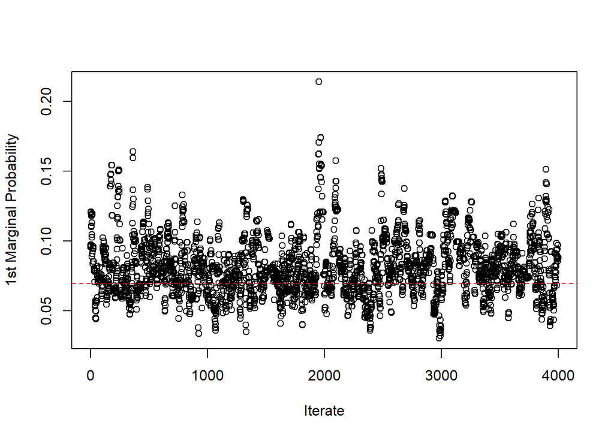

```r
plot(samps$marg_probs[-c(1:1000),1], ylab = "1st Marginal Probability", xlab = "Iterate")
abline(h = freq[1]/N, col = "red", lty = "dashed")
```

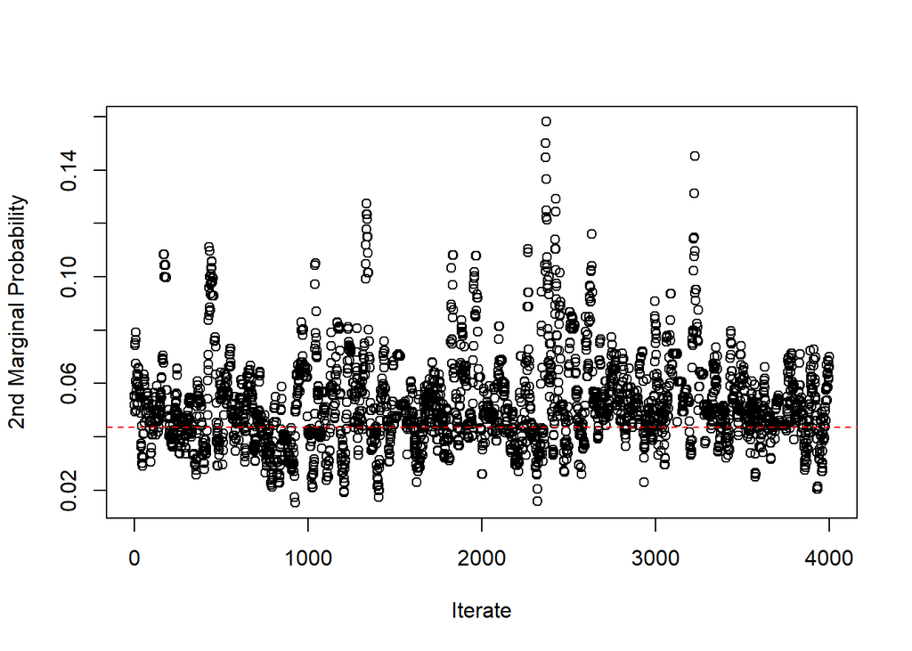

```r
plot(samps$marg_probs[-c(1:1000),2], ylab = "2nd Marginal Probability", xlab = "Iterate")
abline(h = freq[2]/N, col = "red", lty = "dashed")
```